# *Taller*: Análisis y visualización de datos de violencia intrafamiliar contra mujeres

## por [Sarahí Aguilar](https://www.linkedin.com/in/sarahi-aguilar/)

#### [Rladies CDMX](https://www.meetup.com/es/rladies-cdmx/) Junio 2021

> **Descripción**  
> En este taller, revisaremos un breve panorama de la violencia en el ámbito familiar contra la mujer en México, analizando datos y construyendo visualizaciones con cifras de: (1) la Encuesta Nacional sobre la Dinámica de las Relaciones en los Hogares (ENDIREH) 2016 y (2) los Reportes de incidencia delictiva al mes de mayo 2021 del Secretariado Ejecutivo del Sistema Nacional de Seguridad Pública (SESNSP).

> **Objetivo**  
> El objetivo de este taller es que sus asistentes se familiaricen con las bases de datos y librerías de código en R empleadas en él, y con ello, puedan contar con las herramientas y la noción del flujo de preprocesamiento y análisis de datos para bases de datos similares.

> **Librerías a utilizar**  
> `data.table`, `ggplot2`, `mxmaps`, `scales`, `ggridges`, `forcats`, `lubridate`

## Definición de violencia en el ámbito familiar

> *Se refiere a las agresiones o maltrato sufrido por las mujeres de 15 y más años de edad, en los últimos 12 meses, por parte de miembros de su familia o del esposo (como hermanos, cuñados, suegros, padrinos) sin considerar el maltrato de su pareja.*

> *El 8.1% de las mujeres experimentó violencia emocional en su familia en el último año.*

Fuente: [INEGI](https://www.inegi.org.mx/app/glosario/default.html?p=ENDIREH2016)

## Trabajando con datos de la Encuesta Nacional sobre la Dinámica de las Relaciones en los Hogares (ENDIREH) 2016

> En el marco del Sistema Nacional de Información Estadística y Geográfica, el Instituto Nacional de Estadística y Geografía (INEGI), llevó a cabo en el último trimestre de 2016, la cuarta Encuesta Nacional sobre la Dinámica de las Relaciones en los Hogares 2016 (ENDIREH-2016).  
> Esta encuesta ofrece a la sociedad y al estado información referente a las **experiencias de violencia de tipo físico, económico, sexual, emocional y patrimonial**, que han enfrentado las **mujeres de 15 años y más** en los distintos ámbitos de su vida (de pareja, **familiar**, escolar, laboral y comunitario) y recopila información, sobre los agresores y los lugares donde ocurrieron las agresiones.

Fuente: [INEGI](https://www.inegi.org.mx/programas/endireh/2016/#Documentacion)

### Descarga

1. Entrar a la [página del INEGI](https://www.inegi.org.mx/default.html). > Dar click en el módulo de *Datos*. > Dar click en el submódulo de *Programas*. > Dar click en el botón de *Encuestas en Hogares*. > Desplegar las opciones de *Regulares*. > Desplegar las opciones de *Encuesta Nacional sobre la Dinámica de las Relaciones en los Hogares (ENDIREH)*. > Dar click en el botón de *2016*.
2. Una vez en la [sección de la ENDIREH 2016](https://www.inegi.org.mx/programas/endireh/2016/), dar click en el módulo de *Datos abiertos*, dar click en el *botón para descargar todos los archivos en una carpeta zip*.
3. Descomprimir la carpeta de datos descargada.

**Recomendación**: Explorar la estructura de la carpeta de datos descargada, y consultar el contenido del módulo de *Documentación*, particularmente los cuestionarios en su *SECCIÓN X. ÁMBITO FAMILIAR*.

### Carga de datos a entorno de R

(Paso previo recomendado:) [Crear un nuevo proyecto de RStudio](https://support.rstudio.com/hc/en-us/articles/200526207-Using-Projects), crear una carpeta de “datos” dentro de la carpeta del proyecto y reubicar la carpeta de datos descargada dentro de esta nueva carpeta de “datos”.

- Instalar/cargar librerías

```r
# Descomentar línea siguiente para instalar todos los paquetes necesarios
# install.packages("data.table", "ggplot2", "mxmaps", "scales")
library(data.table, ggplot2, mxmaps, scales, ggridges, forcats)
```

[output not shown]

**Datos de la Sección X. Ámbito Familiar.**

- Crear nueva variable con ruta a carpeta con datos

```r
path_sec_x <- "../datos/conjunto_de_datos_endireh_2016_csv/conjunto_de_datos_tb_sec_x_endireh_2016"
```

- Cargar diccionario de datos (útil para consulta)

```r
dict_sec_x <- fread(file.path(path_sec_x, "diccionario_de_datos/diccionario_de_datos_tb_sec_x_endireh_2016.csv"), encoding = "UTF-8")

head(dict_sec_x)
```

| NOMBRE_CAMPO | NEMONICO | TIPO | LONGITUD | RANGO_CLAVES |
| --- | --- | --- | --- | --- |
| Identificador de vivienda seleccionada | id_viv | Carácter | 10 | 0100001.01, …, 3299999.99\r |
| Identificador de la mujer | id_muj | Carácter | 16 | 0100001.01.01.01, …, 3299999.99.06.30\r |
| Control de vivienda (UPM) | upm | Carácter | 7 | 0100001, …, 3299999\r |
| Número de renglón de la mujer elegida | ren_m_ele | Carácter | 2 | 01, …, 30\r |
| Vivienda seleccionada | viv_sel | Carácter | 2 | 01, …, 99\r |
| Progresivo de la vivienda seleccionada | prog | Carácter | 3 | 001, …, 999\r |

- Cargar conjunto de datos

```r
dt_sec_x <- fread(file.path(path_sec_x, "conjunto_de_datos/conjunto_de_datos_tb_sec_x_endireh_2016.csv"), encoding = "UTF-8")

head(dt_sec_x)
```

| ID_VIV | ID_MUJ | UPM | REN_M_ELE | VIV_SEL | PROG | HOGAR | DOMINIO | CVE_ENT | NOM_ENT | CVE_MUN | NOM_MUN | COD_RES | COD_RES_MU | T_INSTRUM | P10_1_1 | P10_1_2 | P10_1_3 | P10_1_4 | P10_1_5 | P10_1_6 | P10_1_7 | P10_1_8 | P10_1_9 | P10_1_10 | P10_1_11 | P10_1_12 | P10_1_13 | P10_1_14 | P10_1_15 | … |
| --- | --- | --- | --- | --- | --- | --- | --- | --- | --- | --- | --- | --- | --- | --- | --- | --- | --- | --- | --- | --- | --- | --- | --- | --- | --- | --- | --- | --- | --- | --- |
| 0100090.04\r | 0100090.04.01.02\r | 0100090\r | 02\r | 04\r | 078\r | 01\r | U\r | 01\r | Aguascalientes\r | 001\r | Aguascalientes\r | 01\r | 1\r | A1\r | 4\r | 4\r | 4\r | 4\r | 4\r | 4\r | 4\r | 4\r | 4\r | 4\r | 4\r | 4\r | 4\r | 4\r | 4\r | … |
| 0100097.01\r | 0100097.01.01.02\r | 0100097\r | 02\r | 01\r | 018\r | 01\r | U\r | 01\r | Aguascalientes\r | 001\r | Aguascalientes\r | 01\r | 1\r | A1\r | 4\r | 4\r | 4\r | 4\r | 4\r | 4\r | 4\r | 4\r | 4\r | 4\r | 4\r | 4\r | 4\r | 4\r | 4\r | … |
| 0100097.05\r | 0100097.05.01.01\r | 0100097\r | 01\r | 05\r | 121\r | 01\r | U\r | 01\r | Aguascalientes\r | 001\r | Aguascalientes\r | 01\r | 1\r | B1\r | 4\r | 4\r | 4\r | 4\r | 4\r | 4\r | 4\r | 4\r | 3\r | 4\r | 4\r | 4\r | 4\r | 4\r | 4\r | … |
| 0100097.03\r | 0100097.03.01.02\r | 0100097\r | 02\r | 03\r | 130\r | 01\r | U\r | 01\r | Aguascalientes\r | 001\r | Aguascalientes\r | 01\r | 1\r | A1\r | 4\r | 4\r | 4\r | 4\r | 4\r | 3\r | 4\r | 4\r | 4\r | 4\r | 1\r | 4\r | 4\r | 1\r | 4\r | … |
| 0100101.03\r | 0100101.03.01.01\r | 0100101\r | 01\r | 03\r | 033\r | 01\r | U\r | 01\r | Aguascalientes\r | 001\r | Aguascalientes\r | 01\r | 1\r | B2\r | 4\r | 4\r | 4\r | 4\r | 4\r | 4\r | 4\r | 4\r | 4\r | 4\r | 4\r | 4\r | 4\r | 4\r | 4\r | … |
| 0100101.04\r | 0100101.04.01.03\r | 0100101\r | 03\r | 04\r | 051\r | 01\r | U\r | 01\r | Aguascalientes\r | 001\r | Aguascalientes\r | 01\r | 1\r | B1\r | 4\r | 4\r | 4\r | 4\r | 4\r | 4\r | 4\r | 4\r | 4\r | 4\r | 4\r | 4\r | 4\r | 4\r | 4\r | … |

**Datos demográficos generales de la encuesta**

- Crear nueva variable con ruta a carpeta con datos

```r
path_tsdem <- "../datos/conjunto_de_datos_endireh_2016_csv/conjunto_de_datos_tsdem_endireh_2016"
```

- Cargar diccionario de datos (útil para consulta)

```r
tsdem_dict <- fread(file.path(path_tsdem, "diccionario_de_datos/diccionario_de_datos_tsdem_endireh_2016.csv"), encoding = "UTF-8")

head(tsdem_dict)
```

| NOMBRE_CAMPO | NEMONICO | TIPO | LONGITUD | RANGO_CLAVES |
| --- | --- | --- | --- | --- |
| Identificador de vivienda seleccionada | id_viv | Carácter | 10 | 0100001.01, …, 3299999.99\r |
| Identificador de la mujer | id_muj | Carácter | 16 | 0100001.01.01.01, …, 3299999.99.06.30\r |
| Control de vivienda | upm | Carácter | 7 | 0100001, …, 3299999\r |
| Progresivo de la vivienda seleccionada | prog | Carácter | 3 | 001, …, 999\r |
| Vivienda seleccionada | viv_sel | Carácter | 2 | 01, …, 99\r |
| Clave Entidad | cve_ent | Carácter | 2 | 01, …, 32\r |

- Cargar conjunto de datos

```r
dt_tsdem <- fread(file.path(path_tsdem, "conjunto_de_datos/conjunto_de_datos_tsdem_endireh_2016.csv"), encoding = "UTF-8")

head(dt_tsdem)
```

| ID_VIV | ID_MUJ | UPM | PROG | VIV_SEL | CVE_ENT | NOM_ENT | CVE_MUN | NOM_MUN | HOGAR | N_REN | COD_RES | COD_RES_E | NOMBRE | PAREN | SEXO | EDAD | P2_5 | P2_6 | NIV | GRA | P2_8 | P2_9 | P2_10 | P2_11 | P2_12 | P2_13 | P2_14 | P2_15 | P2_16 | … |
| --- | --- | --- | --- | --- | --- | --- | --- | --- | --- | --- | --- | --- | --- | --- | --- | --- | --- | --- | --- | --- | --- | --- | --- | --- | --- | --- | --- | --- | --- | --- |
| 0100006.04\r | 0100006.04.01.02\r | 0100006\r | 039\r | 04\r | 01\r | Aguascalientes\r | 001\r | Aguascalientes\r | 01\r | 02\r | 01\r | 1\r | \r | 3\r | 2\r | 20\r | 01\r | 98\r | 10\r | 1\r | \r | 2\r | 3\r | 2\r | \r | 1\r | \r | 1\r | 6\r | … |
| 0100025.03\r | 0100025.03.02.03\r | 0100025\r | 046\r | 03\r | 01\r | Aguascalientes\r | 001\r | Aguascalientes\r | 02\r | 03\r | 01\r | 1\r | \r | 1\r | 2\r | 42\r | 97\r | 97\r | 4\r | 3\r | \r | 2\r | 3\r | 2\r | \r | 1\r | \r | 1\r | 5\r | … |
| 0100031.05\r | 0100031.05.01.03\r | 0100031\r | 007\r | 05\r | 01\r | Aguascalientes\r | 001\r | Aguascalientes\r | 01\r | 03\r | 01\r | 1\r | \r | 3\r | 2\r | 50\r | 97\r | 01\r | 2\r | 6\r | 1\r | 2\r | 3\r | 2\r | \r | 1\r | \r | 2\r | 3\r | … |
| 0100035.03\r | 0100035.03.02.02\r | 0100035\r | 046\r | 03\r | 01\r | Aguascalientes\r | 001\r | Aguascalientes\r | 02\r | 02\r | 01\r | 1\r | \r | 1\r | 2\r | 44\r | 97\r | 97\r | 3\r | 3\r | \r | 2\r | 3\r | 2\r | \r | 1\r | \r | 1\r | 1\r | … |
| 0100041.01\r | 0100041.01.01.03\r | 0100041\r | 071\r | 01\r | 01\r | Aguascalientes\r | 001\r | Aguascalientes\r | 01\r | 03\r | 01\r | 1\r | \r | 3\r | 2\r | 28\r | 01\r | 96\r | 10\r | 4\r | \r | 2\r | 3\r | 2\r | \r | 1\r | \r | 1\r | 5\r | … |
| 0100126.01\r | 0100126.01.01.02\r | 0100126\r | 016\r | 01\r | 01\r | Aguascalientes\r | 001\r | Aguascalientes\r | 01\r | 02\r | 01\r | 1\r | \r | 2\r | 2\r | 34\r | 96\r | 96\r | 10\r | 4\r | \r | 2\r | 2\r | 2\r | \r | 1\r | \r | 5\r | 5\r | … |

### Seleccionar y reformatear columnas relevantes

**Datos de la Sección X. Ámbito Familiar.**

- Seleccionar columnas de Identificador de la mujer, Clave de entidad federativa, Factor de expansión de las mujeres elegidas y todas las columnas con respuestas de la sección X

```r
# Guardar todos los nombres de columna
all_coln <- names(dt_sec_x)

# Guardar nombres de columna con las respuestas de la sección X
sec_x_coln <- all_coln[grepl("p10_", all_coln, ignore.case = T)]

# Guardar nombres de columna relevantes
rel_coln <- c("ID_MUJ", "CVE_ENT", "FAC_MUJ", sec_x_coln)

# Seleccionar columnas relevantes del conjunto de datos
dt_sec_x <- dt_sec_x[, rel_coln, with = F]
```

- Reformatear datos de columnas relevantes según su tipo de dato

```r
char_coln <- c("ID_MUJ", "CVE_ENT")
dt_sec_x[, char_coln] <- dt_sec_x[, lapply(.SD, function(c) gsub("[\r]", "", c)), .SDcols = char_coln]

num_coln <- c("FAC_MUJ", sec_x_coln)
dt_sec_x[, num_coln] <- dt_sec_x[, lapply(.SD, as.numeric), .SDcols = num_coln]
```

```r
head(dt_sec_x)
```

| ID_MUJ | CVE_ENT | FAC_MUJ | P10_1_1 | P10_1_2 | P10_1_3 | P10_1_4 | P10_1_5 | P10_1_6 | P10_1_7 | P10_1_8 | P10_1_9 | P10_1_10 | P10_1_11 | P10_1_12 | P10_1_13 | P10_1_14 | P10_1_15 | P10_1_16 | P10_1_17 | P10_1_18 | P10_2_1_1 | P10_2_1_2 | P10_2_1_3 | P10_3_1_1 | P10_3_1_2 | P10_3_1_3 | P10_2_2_1 | P10_2_2_2 | P10_2_2_3 | … |
| --- | --- | --- | --- | --- | --- | --- | --- | --- | --- | --- | --- | --- | --- | --- | --- | --- | --- | --- | --- | --- | --- | --- | --- | --- | --- | --- | --- | --- | --- | --- |
| 0100090.04.01.02 | 01 | 72 | 4 | 4 | 4 | 4 | 4 | 4 | 4 | 4 | 4 | 4 | 4 | 4 | 4 | 4 | 4 | 4 | 4 | 4 | NA | NA | NA | NA | NA | NA | NA | NA | NA | … |
| 0100097.01.01.02 | 01 | 82 | 4 | 4 | 4 | 4 | 4 | 4 | 4 | 4 | 4 | 4 | 4 | 4 | 4 | 4 | 4 | 4 | 4 | 4 | NA | NA | NA | NA | NA | NA | NA | NA | NA | … |
| 0100097.05.01.01 | 01 | 82 | 4 | 4 | 4 | 4 | 4 | 4 | 4 | 4 | 3 | 4 | 4 | 4 | 4 | 4 | 4 | 3 | 4 | 4 | NA | NA | NA | NA | NA | NA | NA | NA | NA | … |
| 0100097.03.01.02 | 01 | 82 | 4 | 4 | 4 | 4 | 4 | 3 | 4 | 4 | 4 | 4 | 1 | 4 | 4 | 1 | 4 | 4 | 4 | 4 | NA | NA | NA | NA | NA | NA | NA | NA | NA | … |
| 0100101.03.01.01 | 01 | 94 | 4 | 4 | 4 | 4 | 4 | 4 | 4 | 4 | 4 | 4 | 4 | 4 | 4 | 4 | 4 | 4 | 4 | 4 | NA | NA | NA | NA | NA | NA | NA | NA | NA | … |
| 0100101.04.01.03 | 01 | 189 | 4 | 4 | 4 | 4 | 4 | 4 | 4 | 4 | 4 | 4 | 4 | 4 | 4 | 4 | 4 | 4 | 4 | 4 | NA | NA | NA | NA | NA | NA | NA | NA | NA | … |

**Datos demográficos generales de la encuesta**

- Seleccionar columnas de Identificador de la mujer y Edad

```r
dt_tsdem <- dt_tsdem[, c("ID_MUJ", "EDAD"), with = F]
```

- Reformatear datos de columnas relevantes según su tipo de dato

```r
dt_tsdem[, ID_MUJ := gsub("[\r]", "", ID_MUJ)]
dt_tsdem[, EDAD := as.numeric(EDAD)]
```

```r
head(dt_tsdem)
```

| ID_MUJ | EDAD |
| --- | --- |
| 0100006.04.01.02 | 20 |
| 0100025.03.02.03 | 42 |
| 0100031.05.01.03 | 50 |
| 0100035.03.02.02 | 44 |
| 0100041.01.01.03 | 28 |
| 0100126.01.01.02 | 34 |

### **Análisis de prevalencia de violencia familiar por entidad federativa**

Para este análisis emplearemos las repsuestas a la pregunta 1 de la sección X.

- Crear tabla con total de mujeres por entidad

```r
dt_prev_e <- dt_sec_x[, .(n_poblacion = sum(FAC_MUJ)), by = CVE_ENT]

head(dt_prev_e, n = 32)
```

| CVE_ENT | n_poblacion |
| --- | --- |
| 01 | 484174 |
| 02 | 1301658 |
| 03 | 283466 |
| 04 | 352528 |
| 05 | 1108968 |
| 06 | 278067 |
| 07 | 1857907 |
| 08 | 1363182 |
| 09 | 3756124 |
| 10 | 652059 |

[output cut: 22 more lines]

- Guardar nombres de columna con las respuestas de la pregunta 1

```r
p1_coln <- all_coln[grepl("p10_1_", all_coln, ignore.case = T)]

print(p1_coln)
```

```
 [1] "P10_1_1"  "P10_1_2"  "P10_1_3"  "P10_1_4"  "P10_1_5"  "P10_1_6"  "P10_1_7"  "P10_1_8"  "P10_1_9"  "P10_1_10" "P10_1_11"
[12] "P10_1_12" "P10_1_13" "P10_1_14" "P10_1_15" "P10_1_16" "P10_1_17" "P10_1_18"
```

- Crear conjunto de datos con respuestas de la pregunta 1

```r
dt_p1 <- dt_sec_x[, c("ID_MUJ", "CVE_ENT", "FAC_MUJ", p1_coln), with = F]
```

- Crear nueva variable que señala si la mujer fue violentada al menos 1 vez de alguna forma

```r
dt_p1[, fue_violentada := apply(dt_p1, 1, function(row) any(row %in% c(1, 2, 3)))]

head(dt_p1)
```

| ID_MUJ | CVE_ENT | FAC_MUJ | P10_1_1 | P10_1_2 | P10_1_3 | P10_1_4 | P10_1_5 | P10_1_6 | P10_1_7 | P10_1_8 | P10_1_9 | P10_1_10 | P10_1_11 | P10_1_12 | P10_1_13 | P10_1_14 | P10_1_15 | P10_1_16 | P10_1_17 | P10_1_18 | fue_violentada |
| --- | --- | --- | --- | --- | --- | --- | --- | --- | --- | --- | --- | --- | --- | --- | --- | --- | --- | --- | --- | --- | --- |
| 0100090.04.01.02 | 01 | 72 | 4 | 4 | 4 | 4 | 4 | 4 | 4 | 4 | 4 | 4 | 4 | 4 | 4 | 4 | 4 | 4 | 4 | 4 | FALSE |
| 0100097.01.01.02 | 01 | 82 | 4 | 4 | 4 | 4 | 4 | 4 | 4 | 4 | 4 | 4 | 4 | 4 | 4 | 4 | 4 | 4 | 4 | 4 | FALSE |
| 0100097.05.01.01 | 01 | 82 | 4 | 4 | 4 | 4 | 4 | 4 | 4 | 4 | 3 | 4 | 4 | 4 | 4 | 4 | 4 | 3 | 4 | 4 | TRUE |
| 0100097.03.01.02 | 01 | 82 | 4 | 4 | 4 | 4 | 4 | 3 | 4 | 4 | 4 | 4 | 1 | 4 | 4 | 1 | 4 | 4 | 4 | 4 | TRUE |
| 0100101.03.01.01 | 01 | 94 | 4 | 4 | 4 | 4 | 4 | 4 | 4 | 4 | 4 | 4 | 4 | 4 | 4 | 4 | 4 | 4 | 4 | 4 | FALSE |
| 0100101.04.01.03 | 01 | 189 | 4 | 4 | 4 | 4 | 4 | 4 | 4 | 4 | 4 | 4 | 4 | 4 | 4 | 4 | 4 | 4 | 4 | 4 | FALSE |

- Crear tabla con total de mujeres violentadas al menos 1 vez de alguna forma por entidad

```r
violentadas_e <- dt_p1[fue_violentada == T, .(n_violentadas = sum(FAC_MUJ)), by = CVE_ENT]
```

- Unir con tabla con total de mujeres por entidad

```r
dt_prev_e <- merge(dt_prev_e, violentadas_e, by = "CVE_ENT")
```

- Crear nueva variable de prevalencia de violencia

```r
dt_prev_e[, prevalencia_general := n_violentadas/n_poblacion]
```

```r
head(dt_prev_e, n = 32)
```

| CVE_ENT | n_poblacion | n_violentadas | prevalencia_general |
| --- | --- | --- | --- |
| 01 | 484174 | 60427 | 0.12480431 |
| 02 | 1301658 | 101350 | 0.07786223 |
| 03 | 283466 | 19262 | 0.06795171 |
| 04 | 352528 | 31531 | 0.08944254 |
| 05 | 1108968 | 128370 | 0.11575627 |
| 06 | 278067 | 27049 | 0.09727512 |
| 07 | 1857907 | 140505 | 0.07562542 |
| 08 | 1363182 | 133590 | 0.09799865 |
| 09 | 3756124 | 365126 | 0.09720819 |
| 10 | 652059 | 80950 | 0.12414521 |

[output cut: 22 more lines]

**🔵 Visualización 🔵**

- Cargar datos necesarios del paquete `mxmaps` y unir con tabla con datos de prevalencia de violencia por entidad

```r
data("df_mxstate")

dt_map <- merge(df_mxstate,
                dt_prev_e[, .(CVE_ENT, prevalencia_general)],
                by.x = "region",
                by.y = "CVE_ENT",
                all.x = TRUE)

setnames(dt_map, old = "prevalencia_general", new = "value") # Necesaria para visualización automática
```

```r
head(dt_map, n = 32)
```

|  | region | state_name | state_name_official | state_abbr | state_abbr_official | year | pop | pop_male | pop_female | afromexican | part_afromexican | indigenous | part_indigenous | value |
| --- | --- | --- | --- | --- | --- | --- | --- | --- | --- | --- | --- | --- | --- | --- |
| 1 | 01 | Aguascalientes | Aguascalientes | AGS | Ags. | 2015 | 1312544 | 640091 | 672453 | 653 | 4559 | 153395 | 18716 | 0.12480431 |
| 2 | 02 | Baja California | Baja California | BC | BC | 2015 | 3315766 | 1650341 | 1665425 | 7445 | 10432 | 283055 | 38391 | 0.07786223 |
| 3 | 03 | Baja California Sur | Baja California Sur | BCS | BCS | 2015 | 712029 | 359137 | 352892 | 11032 | 5132 | 103034 | 11728 | 0.06795171 |
| 4 | 04 | Campeche | Campeche | CAMP | Camp. | 2015 | 899931 | 441276 | 458655 | 3554 | 6833 | 400811 | 13140 | 0.08944254 |
| 5 | 05 | Coahuila | Coahuila de Zaragoza | COAH | Coah. | 2015 | 2954915 | 1462612 | 1492303 | 2761 | 8137 | 204890 | 28588 | 0.11575627 |
| 6 | 06 | Colima | Colima | COL | Col. | 2015 | 711235 | 350791 | 360444 | 762 | 3314 | 145297 | 12373 | 0.09727512 |
| 7 | 07 | Chiapas | Chiapas | CHPS | Chis. | 2015 | 5217908 | 2536721 | 2681187 | 4042 | 17265 | 1886104 | 52172 | 0.07562542 |
| 8 | 08 | Chihuahua | Chihuahua | CHIH | Chih. | 2015 | 3556574 | 1752275 | 1804299 | 2738 | 8886 | 401195 | 55433 | 0.09799865 |
| 9 | 09 | Ciudad de México | Distrito Federal | CDMX | DF | 2015 | 8918653 | 4231650 | 4687003 | 160353 | 46958 | 784605 | 175454 | 0.09720819 |
| 10 | 10 | Durango | Durango | DGO | Dgo. | 2015 | 1754754 | 860382 | 894372 | 190 | 11290 | 139407 | 26420 | 0.12414521 |

[output cut: 22 more lines]

- Gener visualización

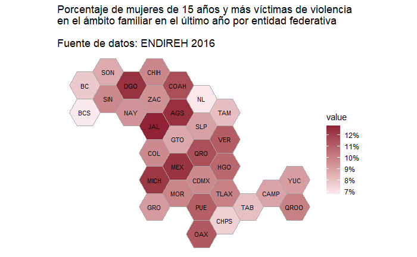

```r
mxhexbin_choropleth(dt_map,
                    num_colors = 1,
                    label_size = 3,
                    title = "Porcentaje de mujeres de 15 años y más víctimas de violencia \nen el ámbito familiar en el último año por entidad federativa\n
Fuente de datos: ENDIREH 2016") +
  scale_fill_gradient(
    low = "#faeaedff",
    high = "#912236ff",
    guide = "colourbar",
    labels = percent_format(accuracy = 1L)
  )
```

### **Análisis de prevalencia de violencia familiar por tipo de violencia**

Para este análisis emplearemos las repsuestas a la pregunta 1 de la sección X.

#### **Tipos y subtipos de violencia**

> **Violencia emocional**  
> - La han ofendido o humillado por el hecho de ser mujer (la hicieron sentir menos o mal)  
> - La han ignorado o no la han tomado en cuenta por ser mujer  
> - Le han roto o escondido algún objeto personal  
> - La han amenazado con hacerle daño a usted o alguien que a usted le importa  
> - La han corrido de su casa o amenazado con correrla  
> - La han encerrado o impedido salir de su casa  
> **Violencia económica o patrimonial**  
> - Le han impedido o prohibido estudiar o trabajar  
> - La han obligado a poner a nombre de otra persona alguna propiedad de usted o le han quitado o robado papeles de alguna propiedad  
> - Le han quitado su dinero o lo han usado sin su consentimiento  
> - Le han quitado bienes o propiedades de usted  
> **Violencia física**  
> - La han pellizcado, jalado el cabello, empujado, jaloneado, abofeteado o aventado algún objeto  
> - La han atacado o agredido con un cuchillo, navaja o arma de fuego  
> - La han pateado o golpeado con el puño  
> **Violencia sexual**  
> - Alguna persona le mostró sus partes íntimas o se las manoseó enfrente de usted  
> - La han obligado a mirar escenas o actos sexuales o pornográficos (fotos, revistas, vídeos o películas pornográficas)  
> - La han manoseado, tocado, besado o se le han arrimado, recargado o encimado sin su consentimiento  
> - Han tratado de obligarla a tener relaciones sexuales en contra de su voluntad  
> - La han obligado a tener relaciones sexuales en contra de su voluntad

Fuente: [INEGI](https://www.inegi.org.mx/app/glosario/default.html?p=ENDIREH2016)

**Datos de violencia emocional**

```r
# Crear nueva variable que señala si la mujer fue violentada al menos 1 vez emocionalmente
p1_emoc_coln <- paste0("P10_1_", c(1, 6, 7, 12, 14, 17))
dt_p1[, fue_violentada_emoc := apply(dt_p1[, p1_emoc_coln, with = F], 1, function(row) any(row %in% c(1, 2, 3)))]

# Crear tabla con total de mujeres violentadas al menos 1 vez emocionalmente por entidad
violentadas_emoc_e <- dt_p1[fue_violentada_emoc == T, .(n_violentadas_emoc = sum(FAC_MUJ)), by = CVE_ENT]

# Unir con tabla con datos por entidad
dt_prev_e <- merge(dt_prev_e, violentadas_emoc_e, by = "CVE_ENT")

# Crear nueva variable de prevalencia de violencia emocional
dt_prev_e[, prevalencia_emocional := n_violentadas_emoc/n_poblacion]
```

```r
head(dt_prev_e, n = 32)
```

| CVE_ENT | n_poblacion | n_violentadas | prevalencia_general | n_violentadas_emoc | prevalencia_emocional |
| --- | --- | --- | --- | --- | --- |
| 01 | 484174 | 60427 | 0.12480431 | 49179 | 0.10157299 |
| 02 | 1301658 | 101350 | 0.07786223 | 76630 | 0.05887107 |
| 03 | 283466 | 19262 | 0.06795171 | 15991 | 0.05641241 |
| 04 | 352528 | 31531 | 0.08944254 | 22810 | 0.06470408 |
| 05 | 1108968 | 128370 | 0.11575627 | 102820 | 0.09271683 |
| 06 | 278067 | 27049 | 0.09727512 | 20677 | 0.07435978 |
| 07 | 1857907 | 140505 | 0.07562542 | 103976 | 0.05596405 |
| 08 | 1363182 | 133590 | 0.09799865 | 106315 | 0.07799032 |
| 09 | 3756124 | 365126 | 0.09720819 | 297995 | 0.07933577 |
| 10 | 652059 | 80950 | 0.12414521 | 62248 | 0.09546375 |

[output cut: 22 more lines]

(Nótese que se continua trabajando sobre la misma tabla a nivel entidad.)

**Datos de violencia económica o patrimonial**

```r
# Crear nueva variable que señala si la mujer fue violentada al menos 1 vez de forma económica o patrimonial
p1_econ_coln <- paste0("P10_1_", c(8, 9, 15, 16))
dt_p1[, fue_violentada_econ := apply(dt_p1[, p1_econ_coln, with = F], 1, function(row) any(row %in% c(1, 2, 3)))]

# Crear tabla con total de mujeres violentadas al menos 1 vez de al menos 1 vez de forma económica o patrimonial por entidad
violentadas_econ_e <- dt_p1[fue_violentada_econ == T, .(n_violentadas_econ = sum(FAC_MUJ)), by = CVE_ENT]

# Unir con tabla con datos por entidad
dt_prev_e <- merge(dt_prev_e, violentadas_econ_e, by = "CVE_ENT")

# Crear nueva variable de prevalencia de violencia económica o patrimonial
dt_prev_e[, prevalencia_economica := n_violentadas_econ/n_poblacion]
```

```r
head(dt_prev_e, n = 32)
```

| CVE_ENT | n_poblacion | n_violentadas | prevalencia_general | n_violentadas_emoc | prevalencia_emocional | n_violentadas_econ | prevalencia_economica |
| --- | --- | --- | --- | --- | --- | --- | --- |
| 01 | 484174 | 60427 | 0.12480431 | 49179 | 0.10157299 | 17844 | 0.03685452 |
| 02 | 1301658 | 101350 | 0.07786223 | 76630 | 0.05887107 | 32578 | 0.02502808 |
| 03 | 283466 | 19262 | 0.06795171 | 15991 | 0.05641241 | 6306 | 0.02224605 |
| 04 | 352528 | 31531 | 0.08944254 | 22810 | 0.06470408 | 10785 | 0.03059331 |
| 05 | 1108968 | 128370 | 0.11575627 | 102820 | 0.09271683 | 40198 | 0.03624812 |
| 06 | 278067 | 27049 | 0.09727512 | 20677 | 0.07435978 | 7229 | 0.02599733 |
| 07 | 1857907 | 140505 | 0.07562542 | 103976 | 0.05596405 | 37178 | 0.02001069 |
| 08 | 1363182 | 133590 | 0.09799865 | 106315 | 0.07799032 | 28790 | 0.02111970 |
| 09 | 3756124 | 365126 | 0.09720819 | 297995 | 0.07933577 | 94563 | 0.02517569 |
| 10 | 652059 | 80950 | 0.12414521 | 62248 | 0.09546375 | 23168 | 0.03553053 |

[output cut: 22 more lines]

**Datos de violencia física**

```r
# Crear nueva variable que señala si la mujer fue violentada al menos 1 vez de forma física
p1_fisi_coln <- paste0("P10_1_", c(5, 10, 11))
dt_p1[, fue_violentada_fisi := apply(dt_p1[, p1_fisi_coln, with = F], 1, function(row) any(row %in% c(1, 2, 3)))]

# Crear tabla con total de mujeres violentadas al menos 1 vez de al menos 1 vez de forma física por entidad
violentadas_fisi_e <- dt_p1[fue_violentada_fisi == T, .(n_violentadas_fisi = sum(FAC_MUJ)), by = CVE_ENT]

# Unir con tabla con datos por entidad
dt_prev_e <- merge(dt_prev_e, violentadas_fisi_e, by = "CVE_ENT")

# Crear nueva variable de prevalencia de violencia física
dt_prev_e[, prevalencia_fisica := n_violentadas_fisi/n_poblacion]
```

```r
head(dt_prev_e, n = 32)
```

| CVE_ENT | n_poblacion | n_violentadas | prevalencia_general | n_violentadas_emoc | prevalencia_emocional | n_violentadas_econ | prevalencia_economica | n_violentadas_fisi | prevalencia_fisica |
| --- | --- | --- | --- | --- | --- | --- | --- | --- | --- |
| 01 | 484174 | 60427 | 0.12480431 | 49179 | 0.10157299 | 17844 | 0.03685452 | 20797 | 0.04295357 |
| 02 | 1301658 | 101350 | 0.07786223 | 76630 | 0.05887107 | 32578 | 0.02502808 | 31383 | 0.02411002 |
| 03 | 283466 | 19262 | 0.06795171 | 15991 | 0.05641241 | 6306 | 0.02224605 | 4972 | 0.01754002 |
| 04 | 352528 | 31531 | 0.08944254 | 22810 | 0.06470408 | 10785 | 0.03059331 | 10019 | 0.02842044 |
| 05 | 1108968 | 128370 | 0.11575627 | 102820 | 0.09271683 | 40198 | 0.03624812 | 39297 | 0.03543565 |
| 06 | 278067 | 27049 | 0.09727512 | 20677 | 0.07435978 | 7229 | 0.02599733 | 7479 | 0.02689640 |
| 07 | 1857907 | 140505 | 0.07562542 | 103976 | 0.05596405 | 37178 | 0.02001069 | 34359 | 0.01849339 |
| 08 | 1363182 | 133590 | 0.09799865 | 106315 | 0.07799032 | 28790 | 0.02111970 | 41508 | 0.03044935 |
| 09 | 3756124 | 365126 | 0.09720819 | 297995 | 0.07933577 | 94563 | 0.02517569 | 118021 | 0.03142095 |
| 10 | 652059 | 80950 | 0.12414521 | 62248 | 0.09546375 | 23168 | 0.03553053 | 27352 | 0.04194712 |

[output cut: 22 more lines]

**Datos de violencia sexual**

```r
# Crear nueva variable que señala si la mujer fue violentada al menos 1 vez de forma sexual
p1_sexu_coln <- paste0("P10_1_", c(2, 3, 4, 13, 18))
dt_p1[, fue_violentada_sexu := apply(dt_p1[, p1_sexu_coln, with = F], 1, function(row) any(row %in% c(1, 2, 3)))]

# Crear tabla con total de mujeres violentadas al menos 1 vez de al menos 1 vez de forma sexual por entidad
violentadas_sexu_e <- dt_p1[fue_violentada_sexu == T, .(n_violentadas_sexu = sum(FAC_MUJ)), by = CVE_ENT]

# Unir con tabla con datos por entidad
dt_prev_e <- merge(dt_prev_e, violentadas_sexu_e, by = "CVE_ENT")

# Crear nueva variable de prevalencia de violencia sexual
dt_prev_e[, prevalencia_sexual := n_violentadas_sexu/n_poblacion]
```

```r
head(dt_prev_e, n = 32)
```

| CVE_ENT | n_poblacion | n_violentadas | prevalencia_general | n_violentadas_emoc | prevalencia_emocional | n_violentadas_econ | prevalencia_economica | n_violentadas_fisi | prevalencia_fisica | n_violentadas_sexu | prevalencia_sexual |
| --- | --- | --- | --- | --- | --- | --- | --- | --- | --- | --- | --- |
| 01 | 484174 | 60427 | 0.12480431 | 49179 | 0.10157299 | 17844 | 0.03685452 | 20797 | 0.04295357 | 6776 | 0.013994969 |
| 02 | 1301658 | 101350 | 0.07786223 | 76630 | 0.05887107 | 32578 | 0.02502808 | 31383 | 0.02411002 | 14061 | 0.010802377 |
| 03 | 283466 | 19262 | 0.06795171 | 15991 | 0.05641241 | 6306 | 0.02224605 | 4972 | 0.01754002 | 3443 | 0.012146077 |
| 04 | 352528 | 31531 | 0.08944254 | 22810 | 0.06470408 | 10785 | 0.03059331 | 10019 | 0.02842044 | 4557 | 0.012926633 |
| 05 | 1108968 | 128370 | 0.11575627 | 102820 | 0.09271683 | 40198 | 0.03624812 | 39297 | 0.03543565 | 16580 | 0.014950837 |
| 06 | 278067 | 27049 | 0.09727512 | 20677 | 0.07435978 | 7229 | 0.02599733 | 7479 | 0.02689640 | 4780 | 0.017190102 |
| 07 | 1857907 | 140505 | 0.07562542 | 103976 | 0.05596405 | 37178 | 0.02001069 | 34359 | 0.01849339 | 19239 | 0.010355201 |
| 08 | 1363182 | 133590 | 0.09799865 | 106315 | 0.07799032 | 28790 | 0.02111970 | 41508 | 0.03044935 | 15283 | 0.011211269 |
| 09 | 3756124 | 365126 | 0.09720819 | 297995 | 0.07933577 | 94563 | 0.02517569 | 118021 | 0.03142095 | 42119 | 0.011213421 |
| 10 | 652059 | 80950 | 0.12414521 | 62248 | 0.09546375 | 23168 | 0.03553053 | 27352 | 0.04194712 | 9569 | 0.014675052 |

[output cut: 22 more lines]

- Exportar tabla completa de prevalencia de violencia familiar por entidad y tipo de violencia

```r
write.csv(dt_prev_e, "../datos/dt_prev_e.csv")
```

- Crear tabla de prevalencia de violencia familiar por tipo de violencia a nivel nacional

```r
dt_prev_mx <- data.table(dt_prev_e[, .(prevalencia_emoc = sum(n_violentadas_emoc)/sum(n_violentadas),
                                       prevalencia_econ = sum(n_violentadas_econ)/sum(n_violentadas),
                                       prevalencia_fisi = sum(n_violentadas_fisi)/sum(n_violentadas),
                                       prevalencia_sexu = sum(n_violentadas_sexu)/sum(n_violentadas))])
```

- Dar formato largo

```r
dt_prev_mx_melted <- melt(dt_prev_mx,
                          variable.name = "tipo_violencia",
                          value.name = "prevalencia")

head(dt_prev_mx_melted)
```

| tipo_violencia | prevalencia |
| --- | --- |
| prevalencia_emoc | 0.7888627 |
| prevalencia_econ | 0.3001547 |
| prevalencia_fisi | 0.2736448 |
| prevalencia_sexu | 0.1101494 |

**🔵 Visualización 🔵**

- Generar visualización

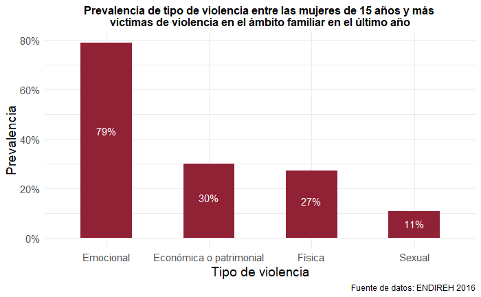

```r
ggplot(dt_prev_mx_melted,
       aes(x = reorder(tipo_violencia, -prevalencia),
           y = prevalencia,
           label = scales::percent(prevalencia, accuracy = 1L))) +
  geom_bar(stat = "identity", width = 0.5, fill = "#912236ff") +
  geom_text(color = "white",  size = 4, position = position_stack(vjust = .55)) +
  scale_y_continuous(labels = scales::percent_format(accuracy = 1L)) +
  labs(title = "Prevalencia de tipo de violencia entre las mujeres de 15 años y más \nvíctimas de violencia en el ámbito familiar en el último año",
       x = "Tipo de violencia",
       y = "Prevalencia",
       caption = "Fuente de datos: ENDIREH 2016") +
  scale_x_discrete(labels = c("prevalencia_emoc" = "Emocional",
                            "prevalencia_econ" = "Económica o patrimonial",
                            "prevalencia_fisi" = "Física",
                            "prevalencia_sexu" = "Sexual")) +
  theme_minimal() +
  theme(plot.title = element_text(size = 12, hjust = 0.5, face = "bold"),
        axis.title = element_text(size = 14),
        axis.text = element_text(size = 11.5))
```

### **Análisis de distribución de edades por tipo de violencia**

Para este análisis emplearemos las repsuestas a la pregunta 1 de la sección X.

- Unir conjunto de datos con respuestas de la pregunta 1 con conjunto de datos de demográficos generales de la encuesta

```r
dt_p1_ <- merge(dt_p1, dt_tsdem, by = "ID_MUJ", all.x = T)
```

- Dar formato largo

```r
dt_p1_melted <- melt(dt_p1_[, c("ID_MUJ", "FAC_MUJ", "EDAD",
                         "fue_violentada_emoc",
                         "fue_violentada_econ",
                         "fue_violentada_fisi",
                         "fue_violentada_sexu")],
                  id = c("ID_MUJ", "FAC_MUJ", "EDAD"),
                  variable.name = "tipo_violencia")

head(dt_p1_melted)
```

| ID_MUJ | FAC_MUJ | EDAD | tipo_violencia | value |
| --- | --- | --- | --- | --- |
| 0100002.01.01.03 | 187 | 16 | fue_violentada_emoc | FALSE |
| 0100002.02.01.02 | 93 | 45 | fue_violentada_emoc | FALSE |
| 0100002.03.01.04 | 187 | 17 | fue_violentada_emoc | TRUE |
| 0100002.05.01.03 | 187 | 18 | fue_violentada_emoc | FALSE |
| 0100003.02.01.01 | 115 | 37 | fue_violentada_emoc | FALSE |
| 0100003.03.01.02 | 115 | 34 | fue_violentada_emoc | FALSE |

- Filtrar casos de violencia

```r
dt_p1_melted <- dt_p1_melted[value == T, ]
```

- Exportar tabla completa de casos de violencia con edad y tipo de violencia

```r
write.csv(dt_p1_melted, "../datos/dt_casos_violencia_con_edad_y_tipo.csv")
```

**🔵 Visualización 🔵**

- Generar visualización

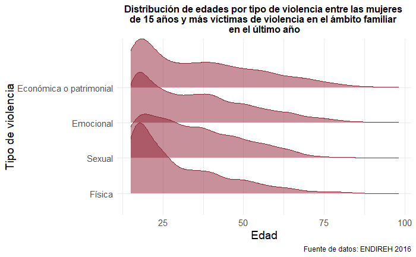

```r
ggplot(dt_p1_melted, aes(x = EDAD, y = fct_reorder(tipo_violencia, EDAD))) +
  geom_density_ridges(scale = 2,
                      color = "#912236ff",
                      fill = "#912236ff",
                      alpha = 0.5,
                      stat = "density",
                      aes(height = ..density..,
                          weight = FAC_MUJ)) +
  scale_y_discrete(labels=c("fue_violentada_emoc" = "Emocional",
                            "fue_violentada_econ" = "Económica o patrimonial",
                            "fue_violentada_fisi" = "Física",
                            "fue_violentada_sexu" = "Sexual")) +
  labs(title = "Distribución de edades por tipo de violencia entre las mujeres \nde 15 años y más víctimas de violencia en el ámbito familiar \nen el último año",
       x = "Edad",
       y = "Tipo de violencia",
       caption = "Fuente de datos: ENDIREH 2016") +
  theme_minimal() +
  theme(plot.title = element_text(size = 12, hjust = 0.5, face = "bold"),
        axis.title = element_text(size = 14),
        axis.text = element_text(size = 11.5))
```

## Trabajando con datos de los Reportes de incidencia delictiva al mes de mayo 2021 del Secretariado Ejecutivo del Sistema Nacional de Seguridad Pública (SESNSP)

### Descarga

1. Entrar a la [página de Datos Abiertos de Incidencia Delictiva](https://www.gob.mx/sesnsp/acciones-y-programas/datos-abiertos-de-incidencia-delictiva). > Dar click en el botón de Cifras de Incidencia Delictiva Estatal, 2015 - [último mes] [año del último mes].
2. Se abrirá una previsualización del archivo (alojado el Google Drive). Dar click en el botón de descarga.
3. Para poder calcular tasas de incidencia, se utilizaron las proyecciones de población a mitad de año del Consejo Nacional de Población. (Conjunto de datos disponible en este repositorio.)

**Recomendación**: Explorar la estructura del archivo descargado, y consultar los [Diccionarios de datos de reportes de incidencia delictiva](https://drive.google.com/file/d/1rfvgcAcEzLR1Q44wwjZhjBvBFjtGSmX3/view).

### Carga de datos a entorno de R

(Paso previo recomendado:) [Crear un nuevo proyecto de RStudio](https://support.rstudio.com/hc/en-us/articles/200526207-Using-Projects), crear una carpeta de “datos” dentro de la carpeta del proyecto y reubicar la carpeta de datos descargada dentro de esta nueva carpeta de “datos”.

**Datos de incidencia delictiva**

- Cargar conjunto de datos

```r
dt_incidencia <- fread("../datos/IDEFC_NM_may21.csv")

head(dt_incidencia)
```

| Año | Clave_Ent | Entidad | Bien jurídico afectado | Tipo de delito | Subtipo de delito | Modalidad | Enero | Febrero | Marzo | Abril | Mayo | Junio | Julio | Agosto | Septiembre | Octubre | Noviembre | Diciembre |
| --- | --- | --- | --- | --- | --- | --- | --- | --- | --- | --- | --- | --- | --- | --- | --- | --- | --- | --- |
| 2015 | 1 | Aguascalientes | La vida y la Integridad corporal | Homicidio | Homicidio doloso | Con arma de fuego | 3 | 0 | 2 | 1 | 1 | 1 | 2 | 1 | 2 | 2 | 2 | 1 |
| 2015 | 1 | Aguascalientes | La vida y la Integridad corporal | Homicidio | Homicidio doloso | Con arma blanca | 1 | 1 | 0 | 0 | 0 | 1 | 0 | 1 | 0 | 0 | 0 | 1 |
| 2015 | 1 | Aguascalientes | La vida y la Integridad corporal | Homicidio | Homicidio doloso | Con otro elemento | 0 | 0 | 2 | 2 | 3 | 2 | 0 | 1 | 2 | 0 | 0 | 0 |
| 2015 | 1 | Aguascalientes | La vida y la Integridad corporal | Homicidio | Homicidio doloso | No especificado | 2 | 0 | 0 | 1 | 0 | 0 | 0 | 0 | 0 | 0 | 0 | 0 |
| 2015 | 1 | Aguascalientes | La vida y la Integridad corporal | Homicidio | Homicidio culposo | Con arma de fuego | 0 | 0 | 0 | 0 | 1 | 0 | 0 | 0 | 0 | 0 | 0 | 0 |
| 2015 | 1 | Aguascalientes | La vida y la Integridad corporal | Homicidio | Homicidio culposo | Con arma blanca | 0 | 0 | 0 | 0 | 0 | 0 | 0 | 0 | 0 | 0 | 0 | 0 |

**Datos de proyección de población**

- Cargar conjunto de datos

```r
dt_poblacion <- fread("../datos/pob_mit_proyecciones.csv", encoding = "UTF-8")

head(dt_poblacion)
```

| RENGLON | ANIO | ENTIDAD | CVE_GEO | EDAD | SEXO | POBLACION |
| --- | --- | --- | --- | --- | --- | --- |
| 1 | 1950 | República Mexicana | 0 | 0 | Hombres | 572103 |
| 2 | 1950 | República Mexicana | 0 | 0 | Mujeres | 559162 |
| 3 | 1950 | República Mexicana | 0 | 1 | Hombres | 514540 |
| 4 | 1950 | República Mexicana | 0 | 1 | Mujeres | 505269 |
| 5 | 1950 | República Mexicana | 0 | 2 | Hombres | 478546 |
| 6 | 1950 | República Mexicana | 0 | 2 | Mujeres | 469322 |

### Seleccionar y reformatear columnas relevantes

**Datos de incidencia delictiva**

```r
# Reemplazar espacios en nombres de columnas
names(dt_incidencia) <- gsub(" ", "_", names(dt_incidencia))

# Filtrar tipo de crimen
dt_incidencia <- dt_incidencia[Tipo_de_delito == "Violencia familiar", ]

# Convertir a formato largo
meses <- c("Enero", "Febrero", "Marzo", "Abril", "Mayo", "Junio",
           "Julio", "Agosto", "Septiembre", "Octubre", "Noviembre", "Diciembre")
setnames(dt_incidencia, old = c("Año", "Entidad"), new = c("anio", "entidad"))
dt_incidencia <- melt.data.table(dt_incidencia,
                                 id.vars = c("anio", "entidad"),
                                 measure.vars = meses,
                                 variable.name = "mes",
                                 value.name = "incidencia")

# Reformatear columna
dt_incidencia[, incidencia := gsub(",", "", incidencia)]
dt_incidencia[, incidencia := as.numeric(incidencia)]

head(dt_incidencia, n = 100)
```

| anio | entidad | mes | incidencia |
| --- | --- | --- | --- |
| 2015 | Aguascalientes | Enero | 29 |
| 2015 | Baja California | Enero | 579 |
| 2015 | Baja California Sur | Enero | 123 |
| 2015 | Campeche | Enero | 1 |
| 2015 | Coahuila de Zaragoza | Enero | 147 |
| 2015 | Colima | Enero | 30 |
| 2015 | Chiapas | Enero | 60 |
| 2015 | Chihuahua | Enero | 723 |
| 2015 | Ciudad de México | Enero | 894 |
| 2015 | Durango | Enero | 151 |

[output cut: 90 more lines]

**Datos de proyección de población**

```r
# Reemplazar espacios en nombres de columnas
names(dt_poblacion) <- gsub(" ", "_", names(dt_poblacion))

# Filtrar para 2015, 2016, 2017, 2018, 2019 y 2020
dt_poblacion <- dt_poblacion[ANIO >= 2015 & ANIO <= 2021, ]

# Sumar cifras de todos los segmentos por año
dt_poblacion <- dt_poblacion[, .(poblacion = sum(POBLACION)), by = .(ANIO, ENTIDAD)]
dt_poblacion[ENTIDAD == "Quertaro", ENTIDAD := "Querétaro"]

# Renombrar columnas
setnames(dt_poblacion, old = names(dt_poblacion), new = c("anio", "entidad", "poblacion"))

head(dt_poblacion, n = 100)
```

| anio | entidad | poblacion |
| --- | --- | --- |
| 2015 | República Mexicana | 121347800 |
| 2016 | República Mexicana | 122715165 |
| 2017 | República Mexicana | 124041731 |
| 2018 | República Mexicana | 125327797 |
| 2019 | República Mexicana | 126577691 |
| 2020 | República Mexicana | 127792286 |
| 2021 | República Mexicana | 128972439 |
| 2015 | Aguascalientes | 1331825 |
| 2016 | Aguascalientes | 1355321 |
| 2017 | Aguascalientes | 1375782 |

[output cut: 90 more lines]

### **Análisis de tasa de incididencia de violencia familiar mensual en los últimos años**

- Calcular incidencia de violencia familiar mensual para toda la República mexicana

```r
# Calcular incidencia nacional
dt_incidencia_nacional <- dt_incidencia[, .(incidencia = sum(incidencia)), by = .(anio, mes)]

# Añadir incidencia nacional a tabla de incidencia por entidad
dt_incidencia_nacional[, entidad := "República Mexicana"]
dt_incidencia <- rbind(dt_incidencia, dt_incidencia_nacional)

head(dt_incidencia, n = 100)
```

| anio | entidad | mes | incidencia |
| --- | --- | --- | --- |
| 2015 | Aguascalientes | Enero | 29 |
| 2015 | Baja California | Enero | 579 |
| 2015 | Baja California Sur | Enero | 123 |
| 2015 | Campeche | Enero | 1 |
| 2015 | Coahuila de Zaragoza | Enero | 147 |
| 2015 | Colima | Enero | 30 |
| 2015 | Chiapas | Enero | 60 |
| 2015 | Chihuahua | Enero | 723 |
| 2015 | Ciudad de México | Enero | 894 |
| 2015 | Durango | Enero | 151 |

[output cut: 90 more lines]

- Unir tablas

```r
# Unir yablad
dt <- merge(dt_incidencia, dt_poblacion, by=c("anio", "entidad"), all.x = TRUE)

head(dt, n = 100)
```

| anio | entidad | mes | incidencia | poblacion |
| --- | --- | --- | --- | --- |
| 2015 | Aguascalientes | Enero | 29 | 1331825 |
| 2015 | Aguascalientes | Febrero | 41 | 1331825 |
| 2015 | Aguascalientes | Marzo | 26 | 1331825 |
| 2015 | Aguascalientes | Abril | 41 | 1331825 |
| 2015 | Aguascalientes | Mayo | 35 | 1331825 |
| 2015 | Aguascalientes | Junio | 38 | 1331825 |
| 2015 | Aguascalientes | Julio | 37 | 1331825 |
| 2015 | Aguascalientes | Agosto | 43 | 1331825 |
| 2015 | Aguascalientes | Septiembre | 50 | 1331825 |
| 2015 | Aguascalientes | Octubre | 58 | 1331825 |

[output cut: 90 more lines]

```r
# Calcular presuntos delitos de violencia familiar por cada 1000 habitantes
dt[, tasa_incidencia := incidencia/(poblacion/1000)]

# Añadir columna de fecha en formato correcto (último día de cada mes)
dt$fecha <- ymd(paste(dt$anio, dt$mes, 1, sep="-"))+months(1)-days(1)
```

**🔵 Visualización 🔵**

- Generar visualización

[figure not shown]

```r
# Filter national data and relevant columns
dt_mx <- dt[entidad == "República Mexicana", .(fecha, tasa_incidencia)]

# Filter out november and december 2020 NA records
dt_mx <- dt_mx[complete.cases(dt_mx), ]

library(forecast)
ggseasonplot(ts(dt_mx$tasa_incidencia, c(2015, 1), frequency = 12), year.labels = T, continuous = TRUE) +
  scale_y_continuous(labels = scales::percent_format(accuracy = 1L)) +
  labs(title = "Prevalencia de tipo de violencia entre las mujeres de 15 años y más \nvíctimas de violencia en el ámbito familiar en el último año",
       x = "Tipo de violencia",
       y = "Tasa de incidencia por cada 1,000 habitantes",
       caption = "Fuente de datos: SESNSP y CONAPO") +
  theme_light() +
  theme(plot.title = element_text(size = 12, hjust = 0.5, face = "bold"),
        axis.title = element_text(size = 10),
        axis.text = element_text(size = 11.5))
```